# PM2.5 Emissions Exploratory Data Analysis Course Project 2

### Exploratory Data Analysis Course Project 2

#### You must address the following questions and tasks in your exploratory analysis. For each question/task you will need to make a single plot. Unless specified, you can use any plotting system in R to make your plot.

Download and unzip the file

```r
# Download and unzip the file

fileurl <- "https://d396qusza40orc.cloudfront.net/exdata%2Fdata%2FNEI_data.zip"

download.file(fileurl, destfile = "EPA.zip")

unzip("EPA.zip")
```

#### Question 1

Have total emissions from PM2.5 decreased in the United States from 1999 to 2008? Using the base plotting system, make a plot showing the total PM2.5 emission from all sources for each of the years 1999, 2002, 2005, and 2008. Upload a PNG file containing your plot addressing this question.

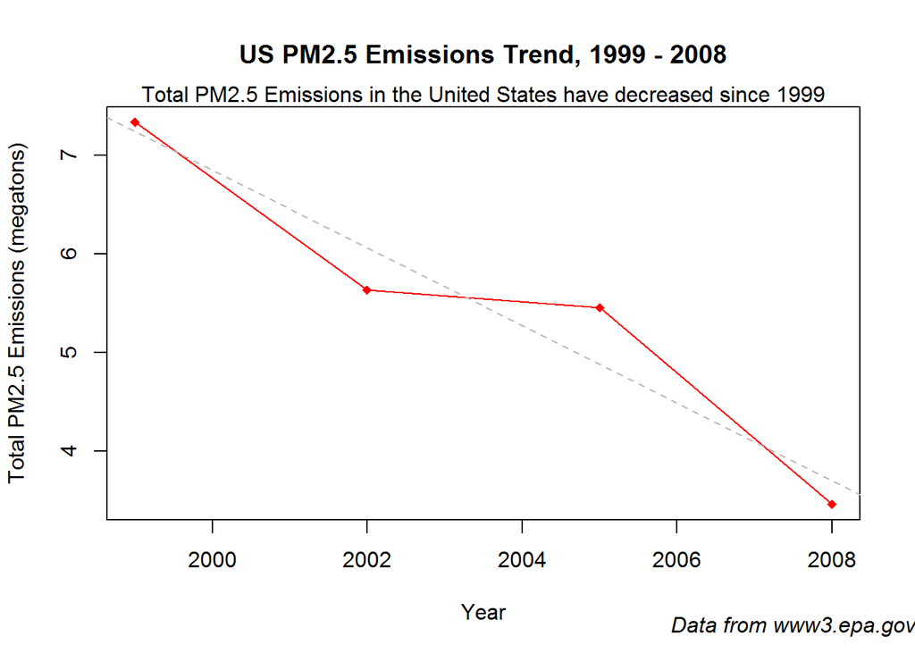

```r
# Load the Datasets

NEI <- readRDS("summarySCC_PM25.rds")

SCC <- readRDS("Source_Classification_Code.rds")

# Merge and join the two datasets together

data <- as.tibble(inner_join(NEI, SCC, by = "SCC"))

# Group the datasets to get to Total US Emissions by year
data2 <- data %>%
  group_by(year) %>%
  summarise(Emissions = sum(Emissions, na.rm = TRUE))

# Create plot1 (line chart)
with(data2, plot(year, Emissions/10^6, type = "l", col = "red",
                 main = "US PM2.5 Emissions Trend, 1999 - 2008",
                 xlab = "Year",
                 ylab = "Total PM2.5 Emissions (megatons)"))
with(data2, points(year, Emissions/10^6, pch = 18, col = "red")) #
with(data2, abline(lm(Emissions/10^6 ~ year, data2), lty = "dashed", col = "grey")) # add regression line
mtext("Total PM2.5 Emissions in the United States have decreased since 1999") # add subtitle
mtext("Data from www3.epa.gov", side=1, line=3.5, at=2007.5, font = 3) # add caption
```

#### Questions 2

Have total emissions from PM2.5 decreased in the Baltimore City, Maryland (fips == “24510”) from 1999 to 2008? Use the base plotting system to make a plot answering this question.

```r
# Group and filter the datasets to get to Total US Emissions by year in Baltimore City.

baltimore_byyear_data <- data %>%
  filter(fips == "24510") %>% # filter to Baltimore City
  group_by(year) %>%
  summarise(Emissions = sum(Emissions, na.rm = TRUE))
```

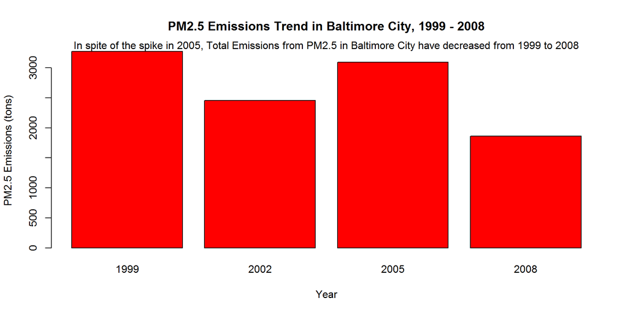

```r
# Create plot2 (bar plot) on screen device

with(baltimore_byyear_data,
     barplot(Emissions, names.arg = year, col = "red",
             main = "PM2.5 Emissions Trend in Baltimore City, 1999 - 2008",
             ylab = "PM2.5 Emissions (tons)",
             xlab = "Year"))
mtext("In spite of the spike in 2005, Total Emissions from PM2.5 in Baltimore City have decreased from 1999 to 2008") # add subtitle
```

#### Questions 3

Of the four types of sources indicated by the type (point, nonpoint, onroad, nonroad) variable, which of these four sources have seen decreases in emissions from 1999-2008 for Baltimore City? Which have seen increases in emissions from 1999-2008? Use the ggplot2 plotting system to make a plot answer this question.

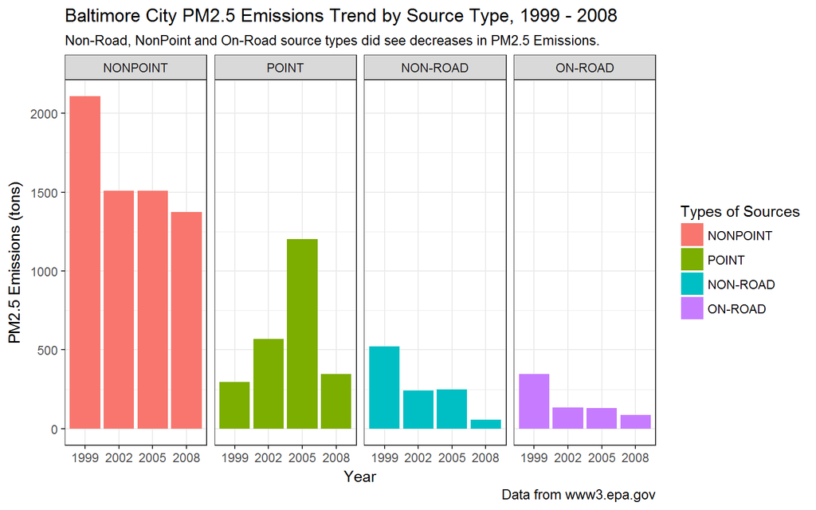

```r
data %>%
  filter(fips == "24510") %>% #Filter to Baltimore City
  group_by(type, year) %>%
  summarise(Emissions = sum(Emissions, na.rm = TRUE)) %>%
  mutate(type_f = factor(type, levels=c('NONPOINT','POINT','NON-ROAD','ON-ROAD'))) %>% # Create a new factor variable of "type" to modify the factor order
  ggplot(aes(as.factor(year), Emissions, fill = type_f)) +
  geom_col() +
  facet_grid(.~type_f) +
  labs(title = "Baltimore City PM2.5 Emissions Trend by Source Type, 1999 - 2008",
       subtitle = "Non-Road, NonPoint and On-Road source types did see decreases in PM2.5 Emissions. ",
       x = "Year",
       y = "PM2.5 Emissions (tons)",
       fill = "Types of Sources",
       caption = "Data from www3.epa.gov") +
  theme_bw()
```

#### Questions 4

Across the United States, how have emissions from coal combustion-related sources changed from 1999-2008?

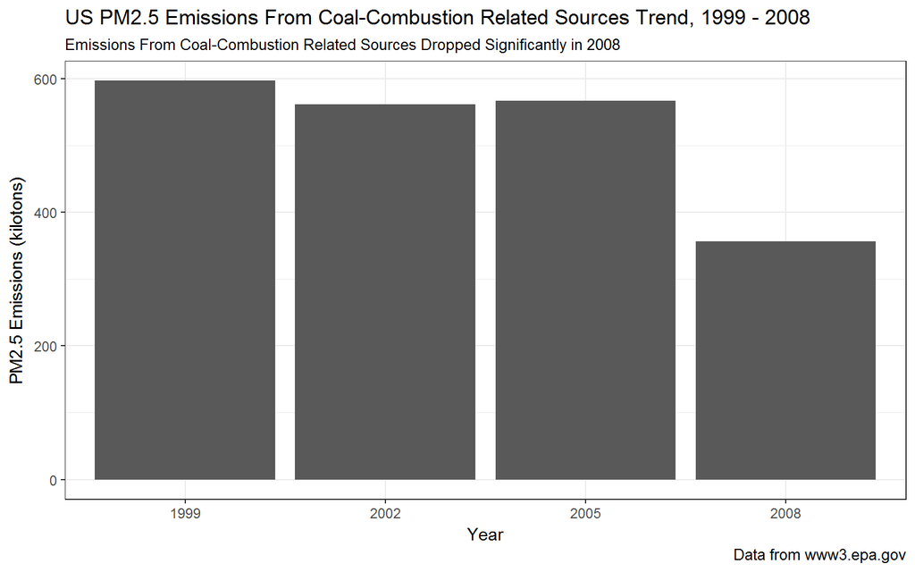

```r
data %>%
  filter(grepl("Coal", Short.Name)) %>% # Filter for observations that contain "Coal" in the Short.Name variable.
  group_by(year) %>%
  summarise(Emissions = sum(Emissions, na.rm = TRUE)) %>%
  ggplot(aes(as.factor(year), Emissions/10^3)) +
  geom_col() +
  labs(title = "US PM2.5 Emissions From Coal-Combustion Related Sources Trend, 1999 - 2008",
       subtitle = "Emissions From Coal-Combustion Related Sources Dropped Significantly in 2008",
       x = "Year",
       y = "PM2.5 Emissions (kilotons)",
       caption = "Data from www3.epa.gov") +
  theme_bw()
```

#### Questions 5

How have emissions from motor vehicle sources changed from 1999-2008 in Baltimore City?

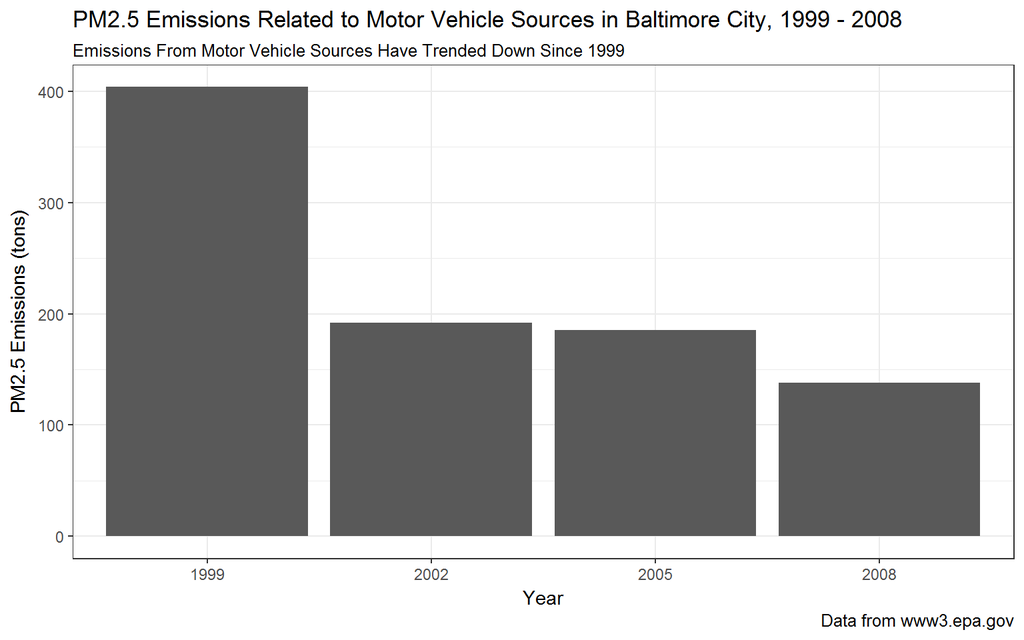

```r
data %>%
  filter(fips == "24510") %>%
  filter(grepl("Vehicle", SCC.Level.Two)) %>% # Filtering under the assumption that off-highway/non-road vehicles also constitute as "Motor Vehicles"
  group_by(year) %>%
  summarise(Emissions = sum(Emissions, na.rm = TRUE)) %>%
  ggplot(aes(as.factor(year), Emissions)) +
  geom_col() +
  labs(title = "PM2.5 Emissions Related to Motor Vehicle Sources in Baltimore City, 1999 - 2008",
       subtitle = "Emissions From Motor Vehicle Sources Have Trended Down Since 1999",
       x = "Year",
       y = "PM2.5 Emissions (tons)",
       caption = "Data from www3.epa.gov") +
  theme_bw()
```

#### Questions 6

Compare emissions from motor vehicle sources in Baltimore City with emissions from motor vehicle sources in Los Angeles County, California (fips == “06037”). Which city has seen greater changes over time in motor vehicle emissions?

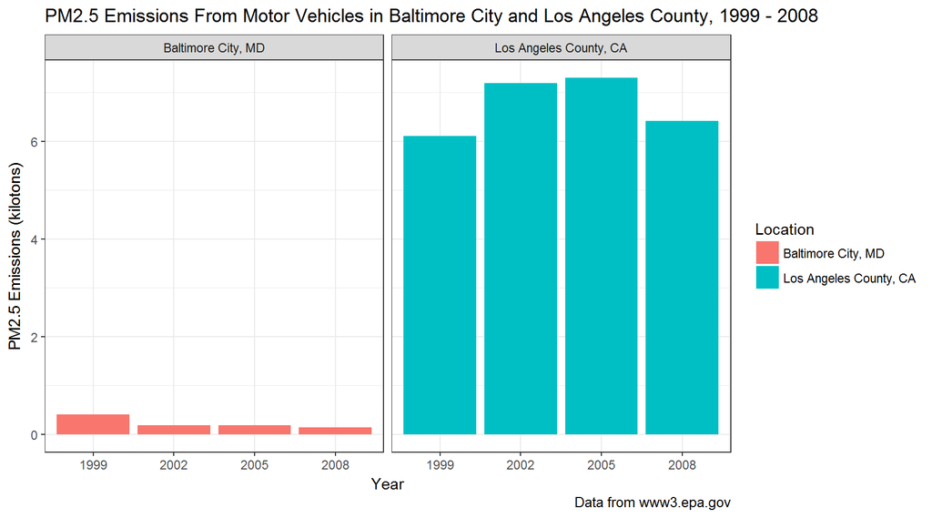

```r
data %>%
  filter(grepl("Vehicle", SCC.Level.Two)) %>% # Filtering under the assumption that off-highway/non-road vehicles also constitute as "Motor Vehicles"
  filter(fips == "24510" | fips == "06037") %>% # filter for LA and Baltimore City
  group_by(fips, year) %>%
  summarise(Emissions = sum(Emissions, na.rm = TRUE)) %>%
  mutate(City = ifelse(fips == "24510", "Baltimore City, MD", ifelse(fips == "06037", "Los Angeles County, CA", "Others"))) %>% # Create a column of the city name
  ggplot(aes(as.factor(year), Emissions/10^3, fill = City)) +
  facet_grid(.~City) +
  geom_col() +
  labs(title = "PM2.5 Emissions From Motor Vehicles in Baltimore City and Los Angeles County, 1999 - 2008",
       x = "Year",
       y = "PM2.5 Emissions (kilotons)",
       fill = "Location",
       caption = "Data from www3.epa.gov") +
  theme_bw()
```